# **Project 3 - Predicting Housing Prices**

### **Introduce the problem**

As population increases and areas across the United States continues to grow, it is getting more difficult to get a grasp on how much you should spend on a house. There are a lot of factors that come into the average pricing of houses in an area, like income and safety. The goal of this project is to better understand demographics and be able to predict the pricing of houses with the data given.

### **Introduce the data**

This dataset contains 80 columns and over 1000 rows of data, based in the city of Ames, Iowa. There are many relevant variables when it comes to house predictions, such as house quality, internal and external conditions, and the month and year the house was sold. We will use this data to get an idea of the house/neighborhood quality in Ames, and predict how much it costs to own a house in the near future.

Starting this project requires installing a few libraries and importing the data itself.

```python
! pip install pandas numpy matplotlib scikit-learn statsmodels seaborn
```

```python
import pandas as pd
import numpy as np
import matplotlib.pyplot as plt
import seaborn as sns
from sklearn.model_selection import train_test_split
from sklearn.preprocessing import StandardScaler, OneHotEncoder
from sklearn.impute import SimpleImputer
from sklearn.metrics import mean_squared_error, r2_score
from sklearn.linear_model import LinearRegression
import statsmodels.api as sm
import os
import warnings
```

```python
# Display options

pd.set_option('display.max_column', None)
warnings.filterwarnings('ignore')
```

Here is the actual dataset imported and a preview of it:

```python
housing_df = pd.read_csv("data/housing_test.csv")
```

```python
housing_df.head()
```

|  | Id | MSSubClass | MSZoning | LotFrontage | LotArea | Street | Alley | LotShape | LandContour | Utilities | LotConfig | LandSlope | Neighborhood | Condition1 | Condition2 | BldgType | HouseStyle | OverallQual | OverallCond | YearBuilt | YearRemodAdd | RoofStyle | RoofMatl | Exterior1st | Exterior2nd | MasVnrType | MasVnrArea | ExterQual | ExterCond | … |
| --- | --- | --- | --- | --- | --- | --- | --- | --- | --- | --- | --- | --- | --- | --- | --- | --- | --- | --- | --- | --- | --- | --- | --- | --- | --- | --- | --- | --- | --- | --- |
| 0 | 1461 | 20 | RH | 80.0 | 11622 | Pave | NaN | Reg | Lvl | AllPub | Inside | Gtl | NAmes | Feedr | Norm | 1Fam | 1Story | 5 | 6 | 1961 | 1961 | Gable | CompShg | VinylSd | VinylSd | NaN | 0.0 | TA | TA | … |
| 1 | 1462 | 20 | RL | 81.0 | 14267 | Pave | NaN | IR1 | Lvl | AllPub | Corner | Gtl | NAmes | Norm | Norm | 1Fam | 1Story | 6 | 6 | 1958 | 1958 | Hip | CompShg | Wd Sdng | Wd Sdng | BrkFace | 108.0 | TA | TA | … |
| 2 | 1463 | 60 | RL | 74.0 | 13830 | Pave | NaN | IR1 | Lvl | AllPub | Inside | Gtl | Gilbert | Norm | Norm | 1Fam | 2Story | 5 | 5 | 1997 | 1998 | Gable | CompShg | VinylSd | VinylSd | NaN | 0.0 | TA | TA | … |
| 3 | 1464 | 60 | RL | 78.0 | 9978 | Pave | NaN | IR1 | Lvl | AllPub | Inside | Gtl | Gilbert | Norm | Norm | 1Fam | 2Story | 6 | 6 | 1998 | 1998 | Gable | CompShg | VinylSd | VinylSd | BrkFace | 20.0 | TA | TA | … |
| 4 | 1465 | 120 | RL | 43.0 | 5005 | Pave | NaN | IR1 | HLS | AllPub | Inside | Gtl | StoneBr | Norm | Norm | TwnhsE | 1Story | 8 | 5 | 1992 | 1992 | Gable | CompShg | HdBoard | HdBoard | NaN | 0.0 | Gd | TA | … |

As we can see, there are many columns and there could be some removed to still acheive our goal.

### **What is regression and how does it work?**

Regression is a method used to have a better understanding of a relationship between a dependent variable (target) and one or more independent variables (predictors). In linear regression, we try to represent this relationship with a straight line.

The formula for linear regression is below: y = β₀ + β₁x + ε

- y is the dependent variable.
- x is the independent variable
- β₀ is the y-intercept, which is the value of y when x = 0
- β₁ is the slope of the line, showing how much y changes when x is increased by 1
- ε is the error term, showing the difference between the actual and predicted value

Linear regression works by finding the line of best fit. The use of this line is to minimize the sum of the squared differences between the actual and predicted data values. This helps us make predictions on new data by plugging x-values into the equation to get an estimated y.

### **Experiment 1**

We will be pre-processing the training file for the first experiment:

```python
housing_train = pd.read_csv("data/housing_train.csv")
```

### **Pre-Processing: Experiment 1**

We need to make sure the "SalePrice" column does exist in this file:

```python
if "SalePrice" not in housing_train.columns:
    raise ValueError("Error: 'SalePrice' column not found in housing_train.csv")
```

```python
housing_train.describe
```

[output not shown]

[output cut: 168 more lines]

```python
housing_train.isna().sum()
```

```
Id                 0
MSSubClass         0
MSZoning           0
LotFrontage      259
LotArea            0
                ...
MoSold             0
YrSold             0
SaleType           0
SaleCondition      0
SalePrice          0
Length: 81, dtype: int64
```

We do have some nulls to deal with, and we will use SimpleImputer to handle this. Before that process begins, we will separate the target variable, SalePrice.

```python
# Separate target variable
X = housing_train.drop(columns=["SalePrice"])
y = housing_train["SalePrice"]
```

We now want to find a way to separate the numerical columns and categorical columns:

```python
numerical_features = X.select_dtypes(include=["number"]).columns
categorical_features = X.select_dtypes(exclude=["number"]).columns
```

Below is the process of using SimpleImputer to deal with these null values.

```python
# Handle missing values
num_imputer = SimpleImputer(strategy="median")
cat_imputer = SimpleImputer(strategy="most_frequent")

X[numerical_features] = num_imputer.fit_transform(X[numerical_features])
X[categorical_features] = cat_imputer.fit_transform(X[categorical_features])
```

We will use OneHotEncoder in order to actually encode these categorical features and convert them into a dataframe.

```python
encoder = OneHotEncoder(sparse_output=False, handle_unknown="ignore")
X_encoded = encoder.fit_transform(X[categorical_features])
encoded_df = pd.DataFrame(X_encoded, columns=encoder.get_feature_names_out(categorical_features))

# Reset index for concatenation
encoded_df.reset_index(drop=True, inplace=True)
X.reset_index(drop=True, inplace=True)
```

The next step in the pre-processing process is to combine the numerical and encoded categorical features:

```python
X_preprocessed = pd.concat([X[numerical_features], encoded_df], axis=1)

# Standardize numerical features
scaler = StandardScaler()
X_scaled = scaler.fit_transform(X_preprocessed)
```

### **Modeling: Experiment 1**

Below is a visualization of feature distribution, specifically the above ground living area:

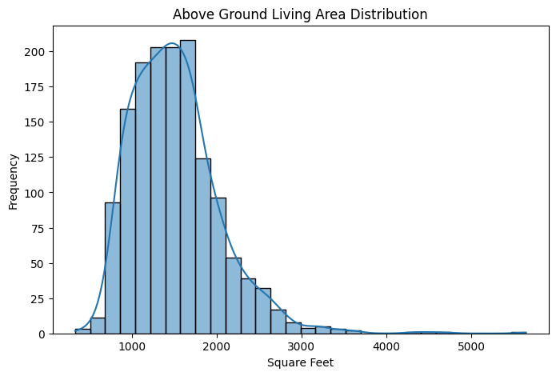

```python
plt.figure(figsize=(8, 5))
sns.histplot(housing_train["GrLivArea"], bins=30, kde=True)
plt.title("Above Ground Living Area Distribution")
plt.xlabel("Square Feet")
plt.ylabel("Frequency")
plt.show()
```

We must split the data into 2 sets, a training and testing set. For this project, we will have 80% for training and 20% for testing.

```python
X_train, X_test, y_train, y_test = train_test_split(X_scaled, y, test_size=0.2, random_state=42)
```

The next step in this process is to train the regression model and predict on the test set:

```python
model = LinearRegression()
model.fit(X_train, y_train)

# Predict on test set
y_pred = model.predict(X_test)
```

### **Evaluation: Experiment 1**

Based on the training done above, we need to evaluate the performance of this regression model.

```python
rmse = np.sqrt(mean_squared_error(y_test, y_pred))
r2 = r2_score(y_test, y_pred)

print(f"RMSE: {rmse:.2f}")
print(f"R² Score: {r2:.2f}")
```

```
RMSE: 28428.97
R² Score: 0.89
```

Based on the evaluation above, we can see that the score is at 89%, which is not too bad. Overall, the score could be better but this experiment leaves us with other options we can take to approach this problem.

### **Experiment 2**

We're going to look at more features that do impact house prices, and see what works best to have more accuracy on predicting these prices. We could look into creating new features as well.

The beginning of this experiment will be to import the necessary libraries and loading the dataset.

```python
from sklearn.ensemble import RandomForestRegressor
from sklearn.linear_model import Ridge
from sklearn.preprocessing import StandardScaler

housing_train = pd.read_csv("data/housing_train.csv")
```

### **Pre-Processing: Experiment 2**

To start with this dataframe, we will drop all non-numeric columns and and fill in all missing values.

```python
housing_train.fillna(0, inplace=True)
```

We will be using a correlation matrix in order to find highly correlated features that go along with SalePrice:

```python
numeric_housing_train = housing_train.select_dtypes(include=[np.number])
correlation_matrix = numeric_housing_train.corr()
top_features = correlation_matrix["SalePrice"].abs().sort_values(ascending=False).index[1:15]
```

With this, we will create new meaningful features, using like TotalSF and HouseAge:

```python
housing_train["TotalSF"] = housing_train["GrLivArea"] + housing_train["TotalBsmtSF"]
housing_train["HouseAge"] = 2024 - housing_train["YearBuilt"]
top_features = list(top_features) + ["TotalSF", "HouseAge"]
```

### **Modeling: Experiment 2**

The next step is to define our target and features, and being training/testing:

```python
X = housing_train[top_features]
y = housing_train["SalePrice"]

X_train, X_test, y_train, y_test = train_test_split(X, y, test_size=0.2, random_state=42)

scaler = StandardScaler()
X_train_scaled = scaler.fit_transform(X_train)
X_test_scaled = scaler.transform(X_test)

lin_reg = LinearRegression()
lin_reg.fit(X_train_scaled, y_train)

# Predictions
y_pred = lin_reg.predict(X_test_scaled)
```

### **Evaluation: Experiment 2**

Similar to the first experiment, we will use R² and MSE to determine the accuracy of this experiment:

```python
rmse = np.sqrt(mean_squared_error(y_test, y_pred))
r2 = r2_score(y_test, y_pred)

print(f"Experiment 2 - Feature Engineering:")
print(f"RMSE: {rmse:.2f}")
print(f"R² Score: {r2:.2f}")
```

```
Experiment 2 - Feature Engineering:
RMSE: 37863.79
R² Score: 0.81
```

Based on the R² score, it looks like this experiment was not as successful and we got less accurate as the first experiment. So far, this is not the ideal approach to take to predict these house prices.

### **Experiment 3**

The last approach we will take is trying Ridge Regression: a regression model that adds a penalty term to the regression to account for multicollinearity.

### **Pre-Processing: Experiment 3**

We will start with training the Ridge Regression model, and we will not need to pre-process our dataframe before beginning this approach.

### **Modeling: Experiment 3**

```python
ridge_reg = Ridge(alpha=1.0)  # Adjust alpha for tuning
ridge_reg.fit(X_train_scaled, y_train)
```

```
Ridge()
```

Below is how we will predict with the Ridge Regression model:

```python
y_pred_ridge = ridge_reg.predict(X_test_scaled)
```

### **Evaluation: Experiment 3**

```python
rmse_ridge = np.sqrt(mean_squared_error(y_test, y_pred_ridge))
r2_ridge = r2_score(y_test, y_pred_ridge)

print(f"Experiment 3 - Ridge Regression:")
print(f"RMSE: {rmse_ridge:.2f}")
print(f"R² Score: {r2_ridge:.2f}")
```

```
Experiment 3 - Ridge Regression:
RMSE: 37863.16
R² Score: 0.81
```

Looking at the R² score for this experiment, it looks like we still get 0.81, which isn't the most accurate score when it comes to predicting with Regression. Compared to the other 2 experiments, this is the 2nd best option to take when it comes to predictions. The R² is the same as the second experiment, and the Root Mean Squared Error is $0.63 less.

### **Impact**

The overall impact of this project and these experiments is to find a calculated and safer approach to predicting future housing prices in Ames, Iowa. This research can help lead to a positive social impact and can help future residents of the city understand and prepare for costs that come with housing in the area. Although the main idea can lead to a positive impact, our results can leave us with a negative impact. If these predictions aren't as accurate, there can be a lot of mistakes and inaccurate representations of costs in Ames, Iowa.

### **Conclusion**

Based on the 3 experiments, 2 of the 3 had a R² score of 0.81, while the first experiment led to a 0.89 R² score. On top of that, the first experiment had the least amount of error with 28,428.97, compared to the 37,000+ in the other 2 experiments. Although this overall may not be the most accurate approach to predicting housing prices, we do have a clear choice of which experiment to stick with. The most optimal approach is to use the baseline linear regression model, with making enough changes during the pre-processing phase of the experiment.

### **References**

- [W3Schools Linear Regression](https://www.w3schools.com/python/python_ml_linear_regression.asp)
- [GeeksForGeeks Ridge Regression](https://www.geeksforgeeks.org/what-is-ridge-regression/)
- [Linear Regression ChatGPT](https://chatgpt.com/)